# ANALISIS PROYECTO BEDU

EQUIPO 4 GRUPO 2(MARTES Y JUEVES)

6/2/2021

# DESCRIPCIÓN DEL PROYECTO

## DESCRIPCIÓN GENERAL

Durante esta etapa del Proyecto se realizaron diversos modelos de series de tiempo $(ARIMA) $para poder llevar a cabo pronósticos y poder entender el tiempo que tardará en recuperarse el empleo de nuestro país.

### SECTORES ECONÓMICOS

Se realizó un análisis desagregado por sectores económicos para poder entender el impacto de la pandemia en cada uno de estos:

### SECTOR PRIMARIO

Para este caso el modelo $ARIMA$ utilizado fue uno de orden:$ (1,0,2)$. Respecto a la gráfica resultante con los pronósticos para 2021 podemos observar que el empleo en este sector tiene un comportamiento muy volátil y esto se aprecia en el pronóstico realizado.

### SECTOR SECUNDARIO

Para este caso el modelo $ARIMA$ utilizado fue uno de orden: $(4,1,0)$. Respecto a la gráfica resultante con los pronósticos para 2021 podemos observar que el empleo en este sector ha tenido una tendencia positiva con una gran caída los para los meses que inició la pandemia, de igual forma podemos observar que para este año no se recuperará por completo el empleo.

### SECTOR TERCIARIO

Para este caso el modelo ARIMA utilizado fue uno de orden:$ (2,1,3)$. Respecto a la gráfica resultante con los pronósticos para 2021 podemos observar que el empleo en este sector tiene un comportamiento con tendencia positiva, pero podemos ver que para este año 2021, el empleo en este sector estará lejos de recuperarse.

### NIVEL DE INGRESO

Se llevó a cabo un análisis desagregado por nivel de ingreso para poder identificar cual fue el nivel de ingreso más afectado por la pandemia.

### MENOS DE UN SALARIO MÍNIMO

Para este caso el modelo $ARIMA$ utilizado fue uno de orden: $(0,1,1)$. Respecto a la gráfica resultante con los pronósticos para 2021 podemos observar que el empleo en este nivel de ingreso tiene un comportamiento muy acelerado con una tendencia positiva y con un alza a partir de que comenzó la pandemia, esto posiblemente se explique ya que, ante la falta de trabajo mejor pagado, mucha gente disminuyó su nivel de ingreso.

#### ENTRE UNO Y DOS SALARIOS MÍNIMOS

Para este caso el modelo $ARIMA$ utilizado fue uno de orden: $(2,1,0)$. Respecto a la gráfica resultante con los pronósticos para 2021 podemos observar que el empleo en este nivel de ingreso al igual que en el anterior tiene un comportamiento muy acelerado con una tendencia positiva y con un alza a partir de que comenzó la pandemia, esto posiblemente se explique ya que, ante la falta de trabajo mejor pagado, mucha gente disminuyó su nivel de ingreso.

#### ENTRE DOS Y TRES SALARIOS MÍNIMOS

Para este caso el modelo $ARIMA$ utilizado fue uno de orden: $(0,1,1)$. Respecto a la gráfica resultante con los pronósticos para 2021 podemos observar que el empleo en este nivel de ingreso tiene un comportamiento cambiante con una gran caída cuando comenzó la pandemia, que no ha podido ni podrá recuperarse este año.

#### ENTRE TRES Y CINCO SALARIOS MÍNIMOS

Para este caso el modelo $ARIMA$ utilizado fue uno de orden: $(0,1,1)$. Respecto a la gráfica resultante con los pronósticos para 2021 podemos observar que el empleo en este nivel de ingreso tiene un comportamiento a la baja, con una gran caída desde que inició la pandemia la cual parece que no ha acabado y se estabilizará este año, pero probablemente ya no se pueda recuperar ese empleo a su nivel previo.

#### MÁS DE CINCO SALARIOS MÍNIMOS

Para este caso el modelo $ARIMA$ utilizado fue uno de orden: $(0,1,1)$. Respecto a la gráfica resultante con los pronósticos para 2021 podemos observar que el empleo en este nivel de ingreso tiene un comportamiento a la baja que parece no haber sido muy afectado por la pandemia y posiblemente este comportamiento se deba a causas más de índole estructural de nuestra economía.

### TAMAÑO DE LA UNIDAD ECONÓMICA

Se llevó a cabo un análisis desagregado por tamaño de la unidad económica para poder identificar cuales fueron las empresas más afectadas durante esta pandemia.

#### MICRONEGOCIOS

Para este caso el modelo $ARIMA$ utilizado fue uno de orden: $(0,1,1)$. Respecto a la gráfica resultante con los pronósticos para 2021 podemos observar que el empleo en estas unidades económicas tuvo una gran caída para el momento inicial de la pandemia, pero tuvo una recuperación muy rápida, y se prevé que este año prácticamente regrese a sus niveles antes de la pandemia.

#### PEQUEÑOS NEGOCIOS

Para este caso el modelo $ARIMA$ utilizado fue uno de orden: $(2,1,2)$. Respecto a la gráfica resultante con los pronósticos para 2021 podemos observar que el empleo en estas unidades económicas tuvo una gran caída para el momento inicial de la pandemia, pero tuvo una recuperación muy rápida, aunque parece que va a tardar varios años en recuperar el nivel que se tenía previo a la pandemia.

#### MEDIANOS NEGOCIOS

Para este caso el modelo $ARIMA$ utilizado fue uno de orden: $(2,1,2)$. Respecto a la gráfica resultante con los pronósticos para 2021 podemos observar que el empleo en estas unidades económicas tuvo una caída moderada para el momento que comenzó la pandemia, aunque ha tenido y se prevé que tenga una recuperación muy lenta.

#### GRANDES NEGOCIOS

Para este caso el modelo $ARIMA$ utilizado fue uno de orden: $(2,1,2)$. Respecto a la gráfica resultante con los pronósticos para 2021 podemos observar que el empleo en estas unidades económicas tuvo una gran caída para el momento que comenzó la pandemia, aunque ha tenido y se prevé que tenga una recuperación lenta, tardando en llegar a su nivel previo.

# DESARROLLO Y ANÁLISIS DEL PROYECTO

Recordemos las preguntas clave que queremos responder con nuestro análisis:

1. ¿Cuál fue el impacto general en el empleo en México?
2. ¿Cuál fue el sector económico más afectado?
3. ¿Cuál fue el sector económico menos afectado?
4. ¿Cuál fue el nivel de ingreso más afectado?
5. ¿Cuál fue el nivel de ingreos menos afectado?
6. ¿Cuál fue el impacto a los negocios, clasificandolos por tamaño?

Para el desarrollo del proyecto tenemos lo siguiente, como primer paso colocamos las librerias que vamos a utilizar:

```r
#install.packages("dplyr")
#install.packages("ggplot2")
#install.packages("forecast")
#install.packages("tseries")
library(dplyr)
library(ggplot2)
library(forecast)
library(tseries)


print("Con la siguiente linea desactivamos la notación científica: ")
options(scipen = 999)
```

La siguiente parte es realizar la lectura de los datos que limpiamos previamente, también obtenemos información del dataset con algunas funciones:

```r
datos<-read.csv("Consolidado.csv")
head(datos)
class(datos)
summary(datos)
dim(datos)
```

[output not shown]

Obtenemos la poblacion total de personas en el pais, y la poblacion que tiene 15 años o mas;

```r
PromedioAnual<-datos %>%  group_by(Año) %>% summarise(PromedioTotal = mean(Población.total), Promedio15oMAS = mean(Población.de.15.años.y.más), n = n())
PromedioAnual<-as.data.frame(PromedioAnual)
class(PromedioAnual)
PromedioAnual
datos
```

[output not shown]

Graficamos la poblacion junto con su creciemnto, Realizamos el analisis para determinar el crecimineto de la poblacion general, con la poblacion que ya genera un ingreso.

Mediante el analisis se afirma que la edad para que una persona genere recursos, es apartir de los 15 años.

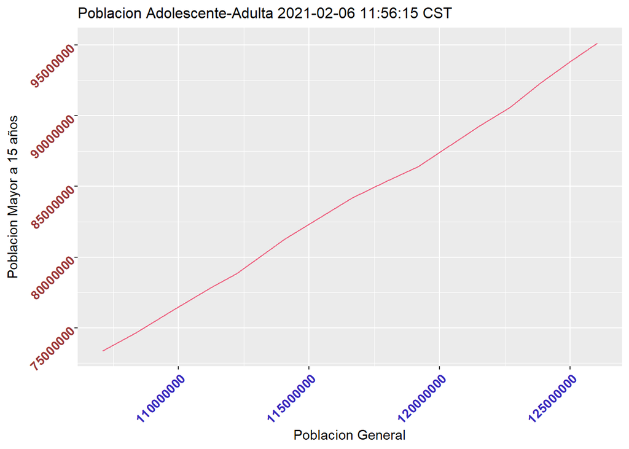

```r
ggplot(PromedioAnual, aes(x=PromedioTotal, y=Promedio15oMAS)) + geom_line(color="blue") +
   labs(x = "Poblacion General",
        y = "Poblacion Mayor a 15 años",
        title = paste("Poblacion Adolescente-Adulta", format(Sys.time(), tz="America/Mexico_City",usetz=TRUE))) +
   geom_line(color = "#ed6381") + theme(plot.title = element_text(size=12)) +
   theme(axis.text.x = element_text(face = "bold", color="#3424bc" , size = 10, angle = 45, hjust = 1),
         axis.text.y = element_text(face = "bold", color="#993333" , size = 10, angle = 45, hjust = 1))  # color, Ángulo y estilo de las abcisas y ordenadas
```

```r
 # color, Ángulo y estilo de las abcisas y ordenadas
```

Hacemos el analisis de la Poblacion Economica Activa y de la no activa mediante los siguientes graficos

```r
PEAPNEA <- select(datos,    Población.económicamente.activa..PEA.:PNEA.No.disponible)
# PEAPNEA
```

Hacemos la agrupacion por año para que la gráficas, sean un poco más limpias para ver si existen patrones:

```r
PoblacionesEconomicas<-NULL
PoblacionesEconomicas<-datos %>%  group_by(Año) %>% summarise(PEAactiva = mean(Población.económicamente.activa..PEA.),
                                                              PNEAactiva = mean(Población.no.económicamente.activa..PNEA.),
                                                              PEAOcupada = mean(PEA.Ocupada),PNEA = mean(PNEA.No.disponible),
                                                              PEAdesocupada = mean(PEA.Desocupada), PNEAdesocupada=mean(PNEA.Disponible),
                                                              n = n())
PoblacionesEconomicas<-as.data.frame(PoblacionesEconomicas)

# PoblacionesEconomicas
```

Poblaciones económicas

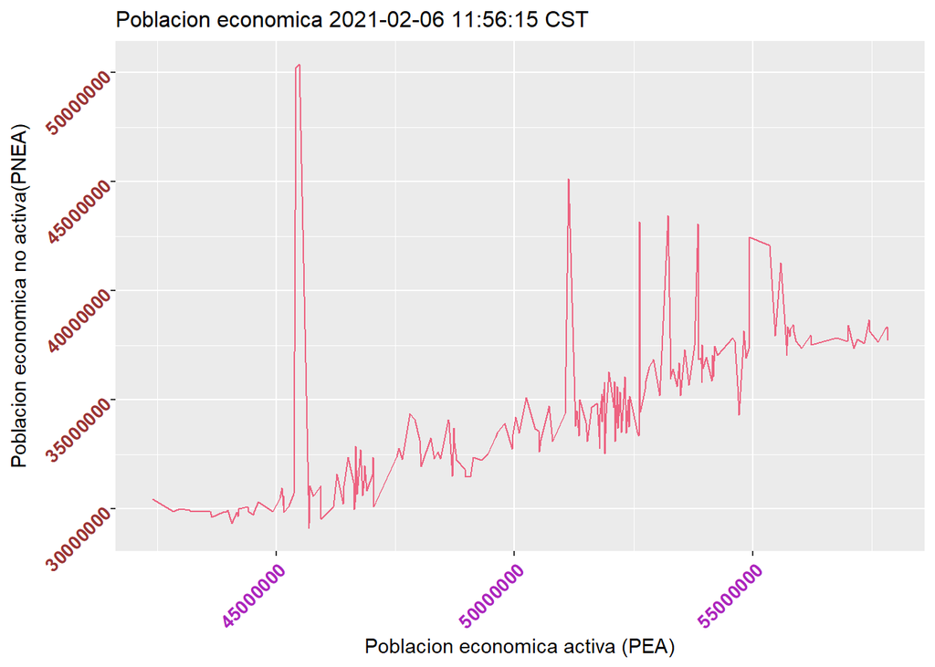

```r
ggplot(PEAPNEA, aes(x=Población.económicamente.activa..PEA., y=Población.no.económicamente.activa..PNEA.)) + geom_line(color="blue") +
   labs(x = "Poblacion economica activa (PEA)",
        y = "Poblacion economica no activa(PNEA)",
        title = paste("Poblacion economica", format(Sys.time(), tz="America/Mexico_City",usetz=TRUE))) +
   geom_line(color = "#ed6381") + theme(plot.title = element_text(size=12)) +
   theme(axis.text.x = element_text(face = "bold", color="#ab24bc" , size = 10, angle = 45, hjust = 1),
         axis.text.y = element_text(face = "bold", color="#993333" , size = 10, angle = 45, hjust = 1))
```

Grafica realizada por año:

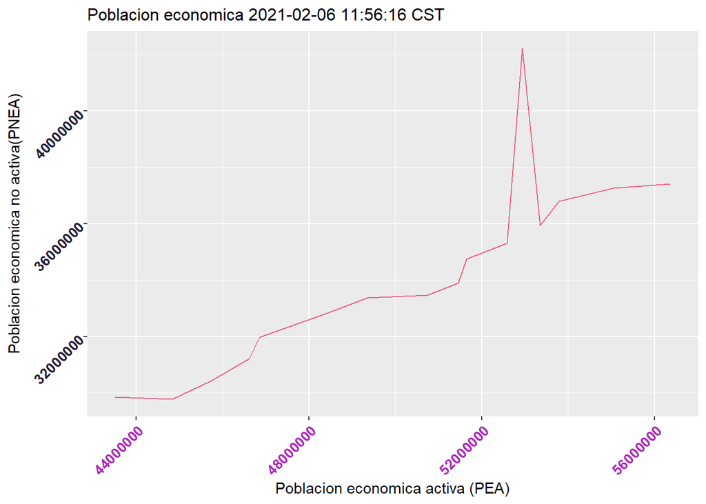

```r
#grafica realizada por a;o
   ggplot(PoblacionesEconomicas, aes(x=PEAactiva, y=PNEAactiva)) + geom_line(color="#acd322") +
   labs(x = "Poblacion economica activa (PEA)",
        y = "Poblacion economica no activa(PNEA)",
        title = paste("Poblacion economica", format(Sys.time(), tz="America/Mexico_City",usetz=TRUE))) +
   geom_line(color = "#ed6381") + theme(plot.title = element_text(size=12)) +
   theme(axis.text.x = element_text(face = "bold", color="#ab24bc" , size = 10, angle = 45, hjust = 1),
         axis.text.y = element_text(face = "bold", color="#221b33" , size = 10, angle = 45, hjust = 1))
```

Cada año de poblacion economica activa

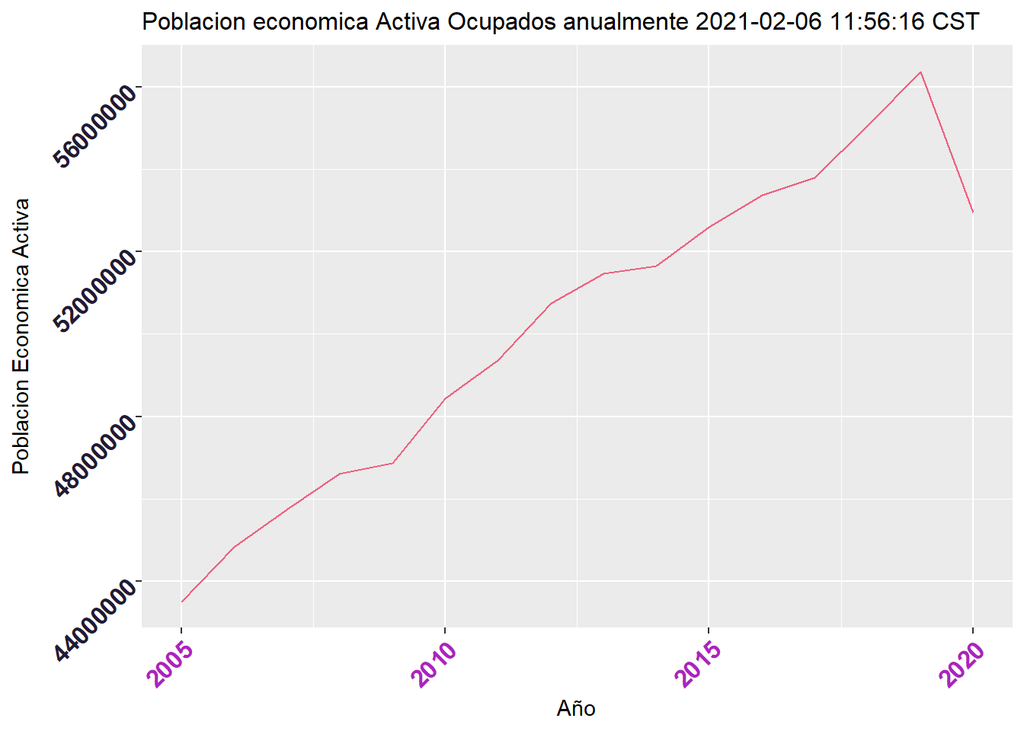

```r
ggplot(PoblacionesEconomicas, aes(x=Año, y=PEAactiva)) + geom_line(color="#acd322") +
      labs(x = "Año",
           y = "Poblacion Economica Activa",
           title = paste("Poblacion economica Activa Ocupados anualmente", format(Sys.time(), tz="America/Mexico_City",usetz=TRUE))) +
      geom_line(color = "#ed6381") + theme(plot.title = element_text(size=12)) +
      theme(axis.text.x = element_text(face = "bold", color="#ab24bc" , size = 12, angle = 45, hjust = 1),
            axis.text.y = element_text(face = "bold", color="#221b33" , size = 12, angle = 45, hjust = 1))
```

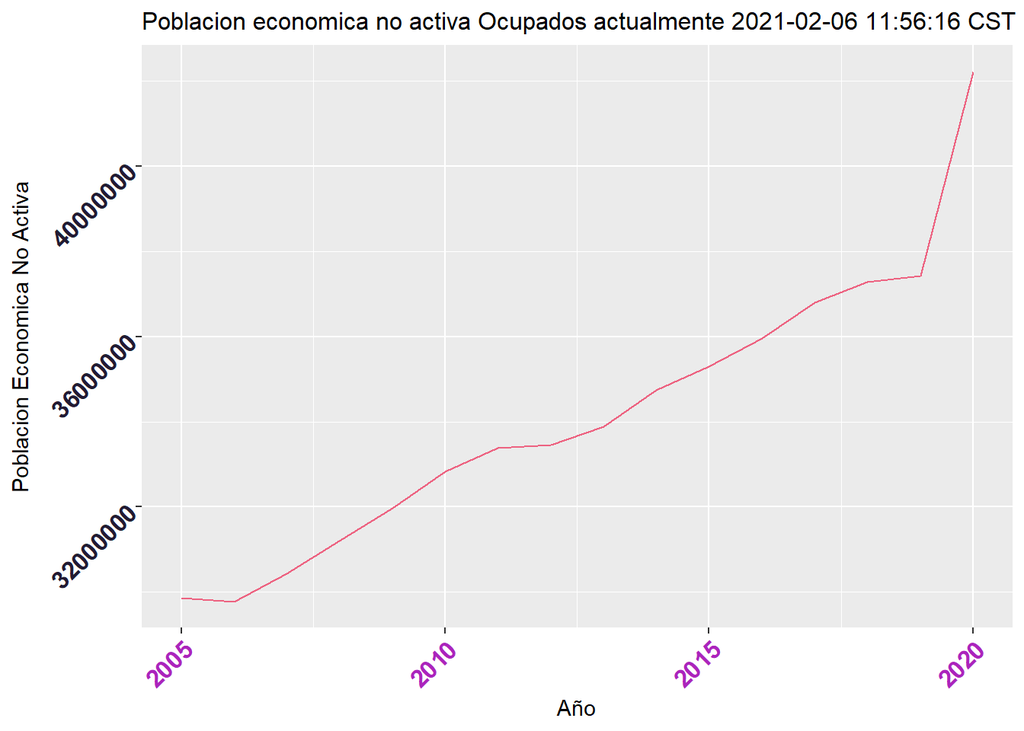

```r
   ggplot(PoblacionesEconomicas, aes(x=Año, y=PNEAactiva)) + geom_line(color="#acd322") +
      labs(x = "Año",
           y = "Poblacion Economica No Activa",
           title = paste("Poblacion economica no activa Ocupados actualmente", format(Sys.time(), tz="America/Mexico_City",usetz=TRUE))) +
      geom_line(color = "#ed6381") + theme(plot.title = element_text(size=12)) +
      theme(axis.text.x = element_text(face = "bold", color="#ab24bc" , size = 12, angle = 45, hjust = 1),
            axis.text.y = element_text(face = "bold", color="#221b33" , size = 12, angle = 45, hjust = 1))
```

Veremos la población económica activa ocupada y la población económica no ocupada.

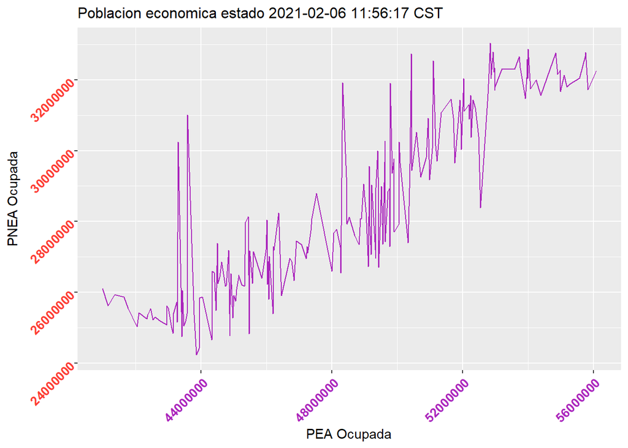

```r
ggplot(PEAPNEA, aes(x=PEA.Ocupada, y=PNEA.No.disponible)) + geom_line(color="blue") +
   labs(x = "PEA Ocupada",
        y = "PNEA Ocupada",
        title = paste("Poblacion economica estado", format(Sys.time(), tz="America/Mexico_City",usetz=TRUE))) +
   geom_line(color = "#aa24bc") + theme(plot.title = element_text(size=12)) +
   theme(axis.text.x = element_text(face = "bold", color="#aa24bc" , size = 10, angle = 45, hjust = 1),
         axis.text.y = element_text(face = "bold", color="#fd3c33" , size = 10, angle = 45, hjust = 1))
```

Grafica realizada por año.

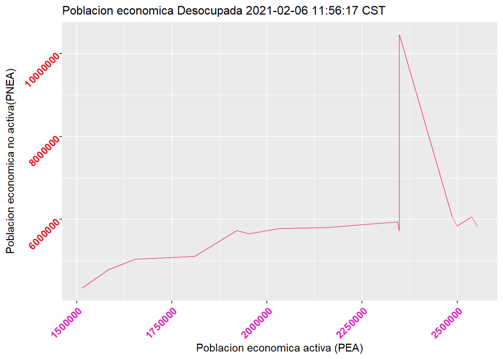

```r
ggplot(PoblacionesEconomicas, aes(x=PEAdesocupada, y=PNEAdesocupada)) + geom_line(color="#aff722") +
   labs(x = "Poblacion economica activa (PEA)",
        y = "Poblacion economica no activa(PNEA)",
        title = paste("Poblacion economica Desocupada", format(Sys.time(), tz="America/Mexico_City",usetz=TRUE))) +
   geom_line(color = "#ed6381") + theme(plot.title = element_text(size=12)) +
   theme(axis.text.x = element_text(face = "bold", color="#db24bc" , size = 10, angle = 45, hjust = 1),
         axis.text.y = element_text(face = "bold", color="#e11b23" , size = 10, angle = 45, hjust = 1))
```

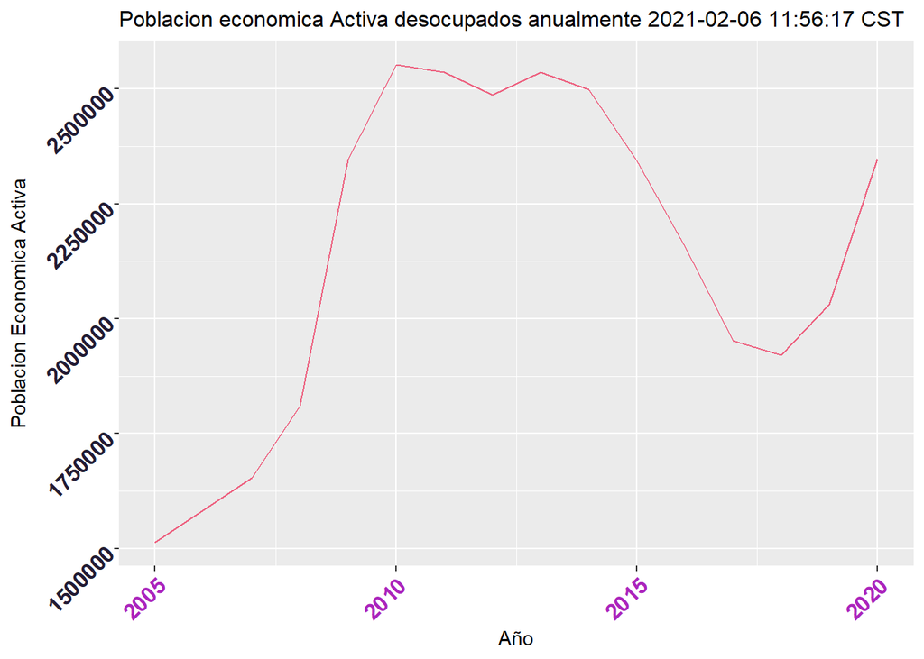

```r
ggplot(PoblacionesEconomicas, aes(x=Año, y=PEAdesocupada)) + geom_line(color="#acd322") +
   labs(x = "Año",
        y = "Poblacion Economica Activa",
        title = paste("Poblacion economica Activa desocupados anualmente", format(Sys.time(), tz="America/Mexico_City",usetz=TRUE))) +
   geom_line(color = "#ed6381") + theme(plot.title = element_text(size=12)) +
   theme(axis.text.x = element_text(face = "bold", color="#ab24bc" , size = 12, angle = 45, hjust = 1),
         axis.text.y = element_text(face = "bold", color="#221b33" , size = 12, angle = 45, hjust = 1))
```

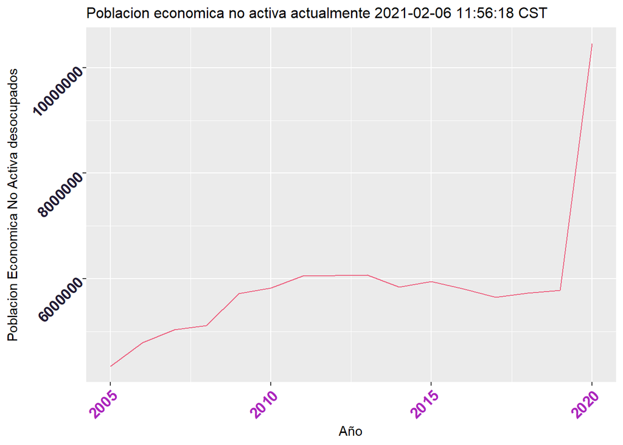

```r
ggplot(PoblacionesEconomicas, aes(x=Año, y=PNEAdesocupada)) + geom_line(color="#acd322") +
   labs(x = "Año",
        y = "Poblacion Economica No Activa desocupados",
        title = paste("Poblacion economica no activa actualmente", format(Sys.time(), tz="America/Mexico_City",usetz=TRUE))) +
   geom_line(color = "#ed6381") + theme(plot.title = element_text(size=12)) +
   theme(axis.text.x = element_text(face = "bold", color="#ab24bc" , size = 12, angle = 45, hjust = 1),
         axis.text.y = element_text(face = "bold", color="#221b33" , size = 12, angle = 45, hjust = 1))
```

Aquí seguimos añadiendo, obtenemos los sectores económicos, vemos como cada sector de la economía ha sido afectado:

```r
Sectores <- select(datos,Año,Primario,Secundario,Terciario)
# Sectores

class(Sectores)
```

```
[1] "data.frame"
```

Calculamos el promedio para obtener el crecimiento anualmente, juntandolo por los años:

```r
Sectores<-Sectores %>%  group_by(Año) %>% summarise(Primario = mean(Primario),
                                                              Secundario = mean(Secundario),
                                                              Terciario = mean(Terciario),
                                                              n = n())
Sectores<-as.data.frame(Sectores)

Sectores
```

```
    Año Primario Secundario Terciario  n
1  2005  6409981   10720704  24550344 12
2  2006  6308014   11159774  25452724 12
3  2007  6232510   11383137  26143147 12
4  2008  6301723   11242067  26912309 12
5  2009  6141876   11104396  26980714  1
6  2010  6522534   11003205  28054149 13
7  2011  6529144   11186733  28792361 13
8  2012  6760804   11403691  29756073 13
9  2013  6753960   11684468  30195126 13
10 2014  6743999   11958347  30163706 13
11 2015  6743035   12402200  30806033 13
12 2016  6712791   12898361  31313483 13
13 2017  6793405   13176863  31567602 13
14 2018  6837318   13512733  32466657 13
15 2019  6803086   13548695  33674125 13
16 2020  6456559   12479938  31382010 13
```

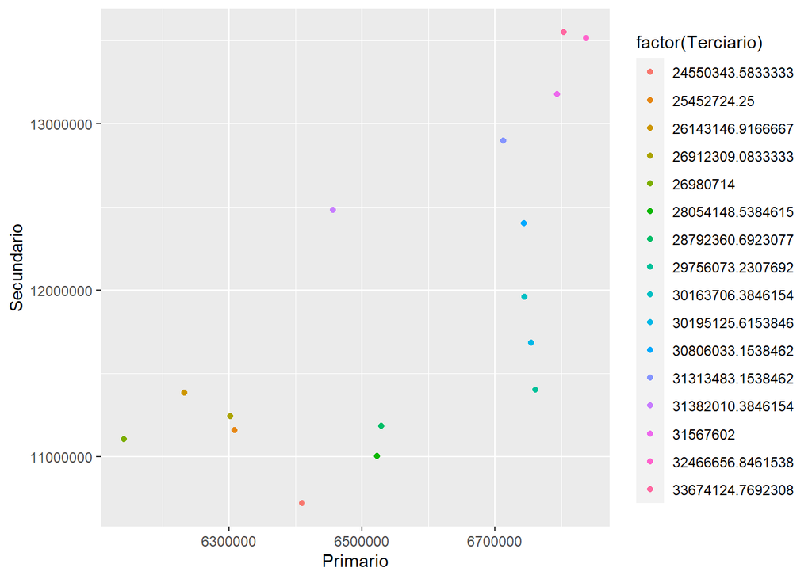

```r
ggplot(Sectores) +
   geom_point(aes(Primario, Secundario, colour = factor(Terciario)))
```

```r
#ggplot(Sectores) + geom_boxplot(aes(x=factor(Año), y=Primario))
```

Graficamos el avance del sector primario en los ultimos años como ha ido creciendo, vemos que en el ultimo año el sector, primario esta descendiendo drasticamente a casi 6500000:

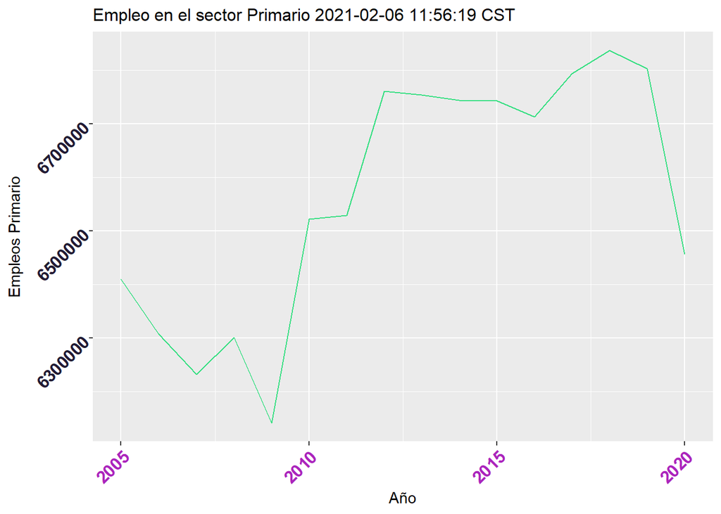

```r
ggplot(Sectores, aes(x=Año, y=Primario)) + geom_line(color="#5cfd22") +
   labs(x = "Año",
        y = "Empleos Primario",
        title = paste("Empleo en el sector Primario", format(Sys.time(), tz="America/Mexico_City",usetz=TRUE))) +
   geom_line(color = "#35df81") + theme(plot.title = element_text(size=12)) +
   theme(axis.text.x = element_text(face = "bold", color="#ab24bc" , size = 12, angle = 45, hjust = 1),
         axis.text.y = element_text(face = "bold", color="#221b33" , size = 12, angle = 45, hjust = 1))
```

Realizamos la siguiente gráfica en el sector secundario para saber cuánto ha perjudicado la pandemia a este sector:

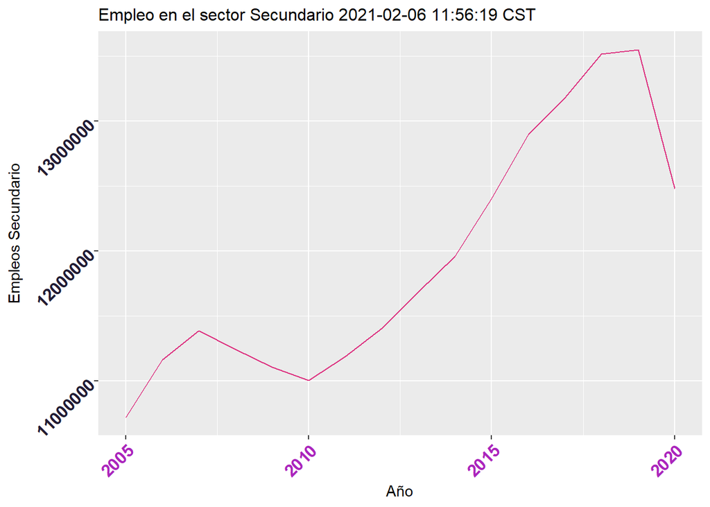

```r
ggplot(Sectores, aes(x=Año, y=Secundario)) + geom_line(color="#dffd22") +
   labs(x = "Año",
        y = "Empleos Secundario",
        title = paste("Empleo en el sector Secundario", format(Sys.time(), tz="America/Mexico_City",usetz=TRUE))) +
   geom_line(color = "#dd3481") + theme(plot.title = element_text(size=12)) +
   theme(axis.text.x = element_text(face = "bold", color="#ab24bc" , size = 12, angle = 45, hjust = 1),
         axis.text.y = element_text(face = "bold", color="#221b33" , size = 12, angle = 45, hjust = 1))
```

Ahora veremos el impacto en el sector terciario:

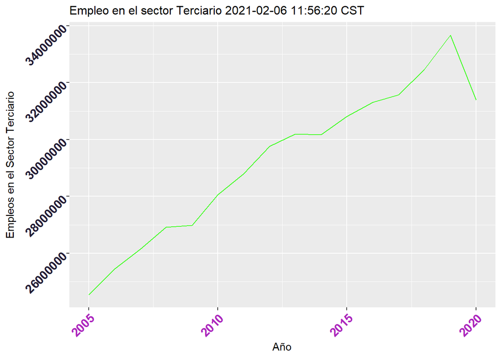

```r
ggplot(Sectores, aes(x=Año, y=Terciario)) + geom_line(color="#dfff22") +
   labs(x = "Año",
        y = "Empleos en el Sector Terciario",
        title = paste("Empleo en el sector Terciario", format(Sys.time(), tz="America/Mexico_City",usetz=TRUE))) +
   geom_line(color = "#3fff21") + theme(plot.title = element_text(size=12)) +
   theme(axis.text.x = element_text(face = "bold", color="#ab24bc" , size = 12, angle = 45, hjust = 1),
         axis.text.y = element_text(face = "bold", color="#221b33" , size = 12, angle = 45, hjust = 1))
```

Calcularemos el crecimiento de cada uno de nuestros Sectores, así veremos como es afectado cada sector:

```r
Sectores <- mutate(Sectores, PrimarioAn = lag(Primario), SecundarioAn = lag(Secundario), TerciarioAn=lag(Terciario))
Sectores
```

```
    Año Primario Secundario Terciario  n PrimarioAn SecundarioAn TerciarioAn
1  2005  6409981   10720704  24550344 12         NA           NA          NA
2  2006  6308014   11159774  25452724 12    6409981     10720704    24550344
3  2007  6232510   11383137  26143147 12    6308014     11159774    25452724
4  2008  6301723   11242067  26912309 12    6232510     11383137    26143147
5  2009  6141876   11104396  26980714  1    6301723     11242067    26912309
6  2010  6522534   11003205  28054149 13    6141876     11104396    26980714
7  2011  6529144   11186733  28792361 13    6522534     11003205    28054149
8  2012  6760804   11403691  29756073 13    6529144     11186733    28792361
9  2013  6753960   11684468  30195126 13    6760804     11403691    29756073
10 2014  6743999   11958347  30163706 13    6753960     11684468    30195126
11 2015  6743035   12402200  30806033 13    6743999     11958347    30163706
12 2016  6712791   12898361  31313483 13    6743035     12402200    30806033
13 2017  6793405   13176863  31567602 13    6712791     12898361    31313483
14 2018  6837318   13512733  32466657 13    6793405     13176863    31567602
15 2019  6803086   13548695  33674125 13    6837318     13512733    32466657
16 2020  6456559   12479938  31382010 13    6803086     13548695    33674125
```

```r
Sectores <- mutate(Sectores, CrePrimario = Primario/PrimarioAn, CrecSecundario = Secundario/SecundarioAn, CrecTerciario= Terciario/TerciarioAn)
Sectores
```

```
    Año Primario Secundario Terciario  n PrimarioAn SecundarioAn TerciarioAn
1  2005  6409981   10720704  24550344 12         NA           NA          NA
2  2006  6308014   11159774  25452724 12    6409981     10720704    24550344
3  2007  6232510   11383137  26143147 12    6308014     11159774    25452724
4  2008  6301723   11242067  26912309 12    6232510     11383137    26143147
5  2009  6141876   11104396  26980714  1    6301723     11242067    26912309
6  2010  6522534   11003205  28054149 13    6141876     11104396    26980714
7  2011  6529144   11186733  28792361 13    6522534     11003205    28054149
8  2012  6760804   11403691  29756073 13    6529144     11186733    28792361
9  2013  6753960   11684468  30195126 13    6760804     11403691    29756073
10 2014  6743999   11958347  30163706 13    6753960     11684468    30195126
11 2015  6743035   12402200  30806033 13    6743999     11958347    30163706
12 2016  6712791   12898361  31313483 13    6743035     12402200    30806033
13 2017  6793405   13176863  31567602 13    6712791     12898361    31313483
14 2018  6837318   13512733  32466657 13    6793405     13176863    31567602
```

[output cut: 19 more lines]

Usaremos estas variables nuevas para ver mas graficamente, el crecimiento de cada Sector, aplicaremos la diferencia a cada una las nuevas columnas, para ver mas a detalle el valor de su crecimiento:

```r
Sectores <- mutate(Sectores, CrePrimarioDif = c(1, diff(CrePrimario)))
# Crecimiento anual del sector Primario
Sectores <- mutate(Sectores, CreSecundarioDif = c(1, diff(CrecSecundario)))
# Crecimiento anual del sector PSecundario
Sectores <- mutate(Sectores, CreTerciarioDif = c(1, diff(CrecTerciario)))
# Crecimiento anual del sector Terciario

Sectores
```

```
    Año Primario Secundario Terciario  n PrimarioAn SecundarioAn TerciarioAn
1  2005  6409981   10720704  24550344 12         NA           NA          NA
2  2006  6308014   11159774  25452724 12    6409981     10720704    24550344
3  2007  6232510   11383137  26143147 12    6308014     11159774    25452724
4  2008  6301723   11242067  26912309 12    6232510     11383137    26143147
5  2009  6141876   11104396  26980714  1    6301723     11242067    26912309
6  2010  6522534   11003205  28054149 13    6141876     11104396    26980714
7  2011  6529144   11186733  28792361 13    6522534     11003205    28054149
8  2012  6760804   11403691  29756073 13    6529144     11186733    28792361
9  2013  6753960   11684468  30195126 13    6760804     11403691    29756073
10 2014  6743999   11958347  30163706 13    6753960     11684468    30195126
11 2015  6743035   12402200  30806033 13    6743999     11958347    30163706
12 2016  6712791   12898361  31313483 13    6743035     12402200    30806033
13 2017  6793405   13176863  31567602 13    6712791     12898361    31313483
14 2018  6837318   13512733  32466657 13    6793405     13176863    31567602
```

[output cut: 36 more lines]

```r
# View(Sectores)
```

Observamos el crecimiento de los sectores, como se mantuvo un crecimiento neutral en el 2015,hasta antes del 2020, parece que entre los a;os 2020 y 2021 puede existir un pico negativo para este sector primario:

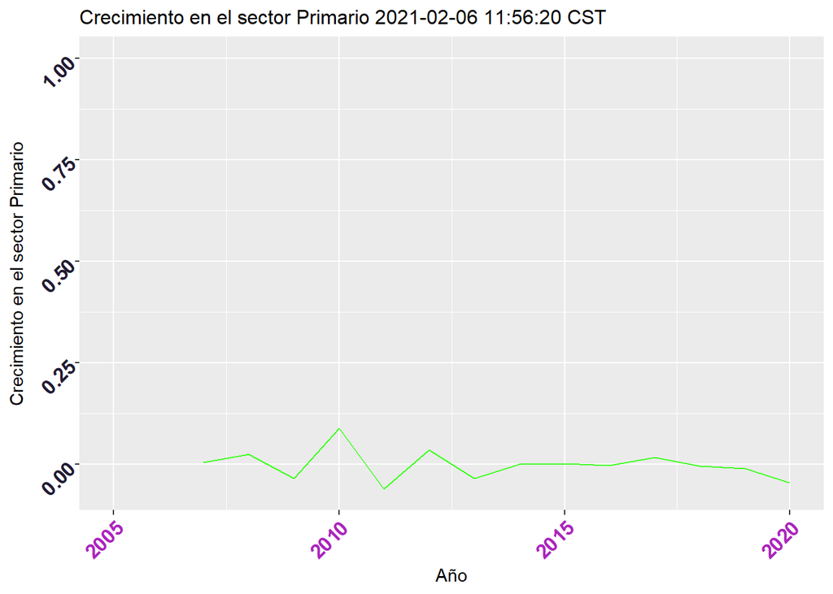

```r
ggplot(Sectores, aes(x=Año, y=CrePrimarioDif)) + geom_line(color="#dfff22") +
   labs(x = "Año",
        y = "Crecimiento en el sector Primario",
        title = paste("Crecimiento en el sector Primario", format(Sys.time(), tz="America/Mexico_City",usetz=TRUE))) +
   geom_line(color = "#3fff21") + theme(plot.title = element_text(size=12)) +
   theme(axis.text.x = element_text(face = "bold", color="#ab24bc" , size = 12, angle = 45, hjust = 1),
         axis.text.y = element_text(face = "bold", color="#221b33" , size = 12, angle = 45, hjust = 1))
```

El sector secundario se ve que es el mas afectado en este a;o, dado que tuvo subidas y bajadas pero nunca un pico notable, solo este 2020 se ve un descenso drástico:

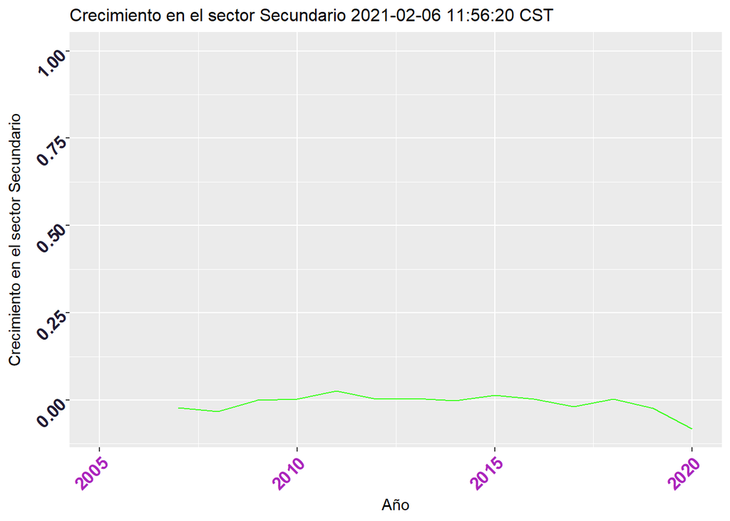

```r
ggplot(Sectores, aes(x=Año, y=CreSecundarioDif)) + geom_line(color="#dfff22") +
   labs(x = "Año",
        y = "Crecimiento en el sector Secundario",
        title = paste("Crecimiento en el sector Secundario", format(Sys.time(), tz="America/Mexico_City",usetz=TRUE))) +
   geom_line(color = "#3fff21") + theme(plot.title = element_text(size=12)) +
   theme(axis.text.x = element_text(face = "bold", color="#ab24bc" , size = 12, angle = 45, hjust = 1),
         axis.text.y = element_text(face = "bold", color="#221b33" , size = 12, angle = 45, hjust = 1))
```

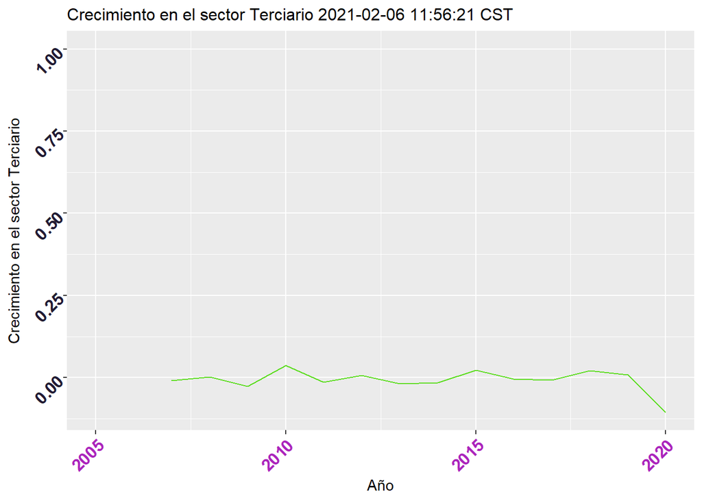

```r
ggplot(Sectores, aes(x=Año, y=CreTerciarioDif)) + geom_line(color="#deee22") +
   labs(x = "Año",
        y = "Crecimiento en el sector Terciario",
        title = paste("Crecimiento en el sector Terciario", format(Sys.time(), tz="America/Mexico_City",usetz=TRUE))) +
   geom_line(color = "#5ddd21") + theme(plot.title = element_text(size=12)) +
   theme(axis.text.x = element_text(face = "bold", color="#ab24bc" , size = 12, angle = 45, hjust = 1),
         axis.text.y = element_text(face = "bold", color="#221b33" , size = 12, angle = 45, hjust = 1))
```

Nivel de ingresos, hasta un salario mínimo, más de 1 hasta 2 salarios mínimos, más de 2 hasta 3 salarios mínimos, más de 3 hasta 5 salarios mínimos más de 5 salarios mínimos, no recibe ingresos, no especificado:

```r
names(datos)
Salarios <- select(datos,Año,X3.3.Nivel.de.ingresos:No.especificado.2)
Salarios

class(Salarios)
names(Salarios)
```

[output not shown]

Calculamos el promedio para obtener el salario promedio anualmente:

```r
Salarios<-Salarios %>%  group_by(Año) %>% summarise(NivelIngreso = mean(X3.3.Nivel.de.ingresos),
                                                    Unsaliriomin = mean(Hasta.un.salario.mínimo),
                                                    uno2salariomin = mean(Más.de.1.hasta.2.salarios.mínimos),
                                                    dos3salariomin = mean(Más.de.2.hasta.3.salarios.mínimos),
                                                    tres5saliomin = mean(Más.de.3.hasta.5.salarios.mínimos),
                                                    Norecibeingreso = mean(No.recibe.ingresos),
                                                    Noescpecificado = mean(No.especificado.2),
                                                    n = n())
Salarios
```

```
# A tibble: 16 x 9
     Año NivelIngreso Unsaliriomin uno2salariomin dos3salariomin tres5saliomin
 * <int>        <dbl>        <dbl>          <dbl>          <dbl>         <dbl>
 1  2005    41998861.     6126837        9530239.       8129345.      7651506.
 2  2006    43254705.     5801405.       9050472.       9557576.      7645717.
 3  2007    44087453.     5664716.       9144702.       9447822.      8136697.
 4  2008    44802662.     5458361.       9113605.      10492803.      7582004.
 5  2009    44510360      5792285       10338469        9084521       7827063
 6  2010    45881179.     6115770.      10690535.       9669582.      7734932.
 7  2011    46821552.     6068582.      10714088.      10005387.      7722547.
 8  2012    48254788.     6594035.      11330859.      10431467.      7334015.
 9  2013    48921267.     6635854.      11794746.      10024682.      7722157.
10  2014    49149041.     6546928.      11753274.      10854666.      7304366.
11  2015    50245531.     6968186.      12486637.      10540230.      7421673.
12  2016    51202741.     7696465.      13405355.      10717560.      6733001.
13  2017    51842983.     7477552       13800844.      10776417.      6735419.
14  2018    53131972.     8492722.      14827378.       9759924.      6935332
15  2019    54339027.    10568038.      16926700.       9888569.      4887141.
16  2020    50587370.    11555278.      17101105.       7655721.      3780147.
# ... with 3 more variables: Norecibeingreso <dbl>, Noescpecificado <dbl>,
#   n <int>
```

```r
#View(Salarios)
class(Salarios)
```

```
[1] "tbl_df"     "tbl"        "data.frame"
```

```r
Salarios<-as.data.frame(Salarios)
names(Salarios)
```

```
[1] "Año"             "NivelIngreso"    "Unsaliriomin"    "uno2salariomin"
[5] "dos3salariomin"  "tres5saliomin"   "Norecibeingreso" "Noescpecificado"
[9] "n"
```

Haremos la grafica de todos los salarios para observar sus cambios, veremos los niveles de ingreso primero, en esto observamos que los a;os anteriores al 2020 eran malos, pero con esta pandemia se ve un gran descenso.

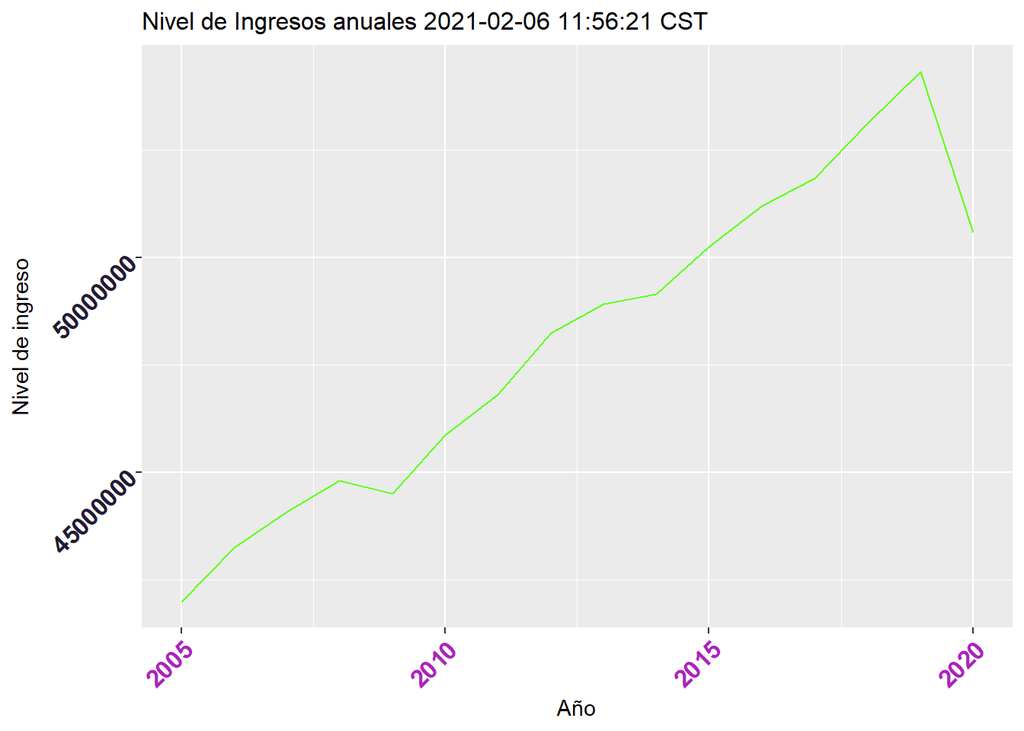

```r
ggplot(Salarios, aes(x=Año, y=NivelIngreso)) + geom_line(color="#723def") +
   labs(x = "Año",
        y = "Nivel de ingreso",
        title = paste("Nivel de Ingresos anuales", format(Sys.time(), tz="America/Mexico_City",usetz=TRUE))) +
   geom_line(color = "#65ff22") + theme(plot.title = element_text(size=12)) +
   theme(axis.text.x = element_text(face = "bold", color="#ab24bc" , size = 12, angle = 45, hjust = 1),
         axis.text.y = element_text(face = "bold", color="#221b33" , size = 12, angle = 45, hjust = 1))
```

Se puede observar que en los ultimos a;os se ha ido incrementado el pago de un solo salario mínimo.

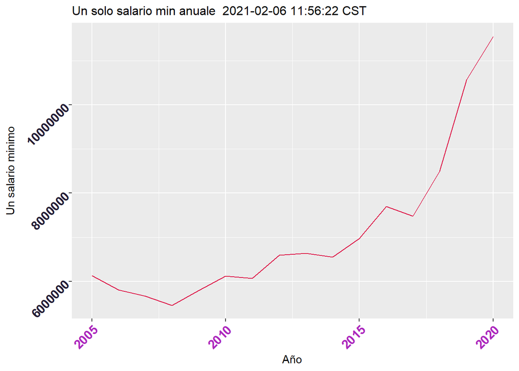

```r
ggplot(Salarios, aes(x=Año, y=Unsaliriomin)) + geom_line(color="red") +
   labs(x = "Año",
        y = "Un salario minimo",
        title = paste("Un solo salario min anuale ", format(Sys.time(), tz="America/Mexico_City",usetz=TRUE))) +
   geom_line(color = "#dd1145") + theme(plot.title = element_text(size=12)) +
   theme(axis.text.x = element_text(face = "bold", color="#ab24bc" , size = 12, angle = 45, hjust = 1),
         axis.text.y = element_text(face = "bold", color="#221b33" , size = 12, angle = 45, hjust = 1))
```

Igual que su antecesor incremento

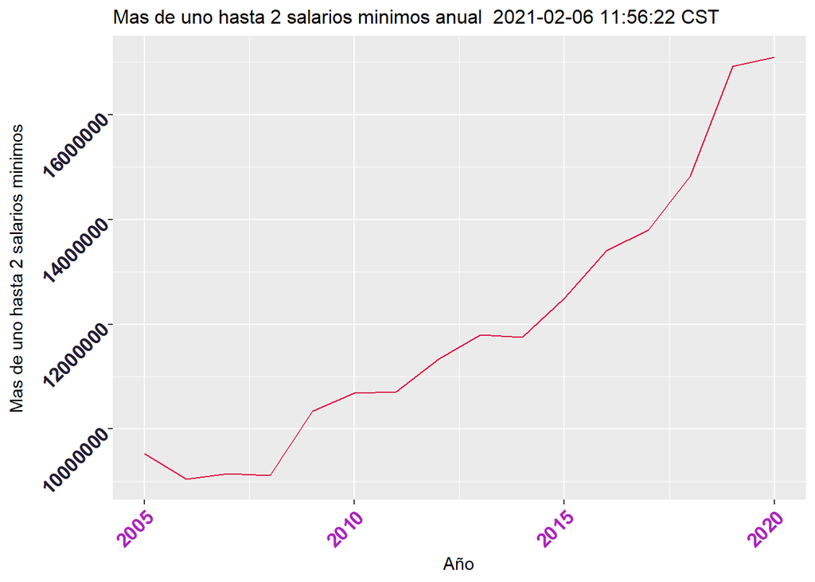

```r
ggplot(Salarios, aes(x=Año, y=Salarios$uno2salariomin)) + geom_line(color="red") +
   labs(x = "Año",
        y = "Mas de uno hasta 2 salarios minimos",
        title = paste("Mas de uno hasta 2 salarios minimos anual ", format(Sys.time(), tz="America/Mexico_City",usetz=TRUE))) +
   geom_line(color = "#dd1145") + theme(plot.title = element_text(size=12)) +
   theme(axis.text.x = element_text(face = "bold", color="#ab24bc" , size = 12, angle = 45, hjust = 1),
         axis.text.y = element_text(face = "bold", color="#221b33" , size = 12, angle = 45, hjust = 1))
```

En este caso se ve un descenso radical en el a;o 2020 y esto puede ser por el covid:

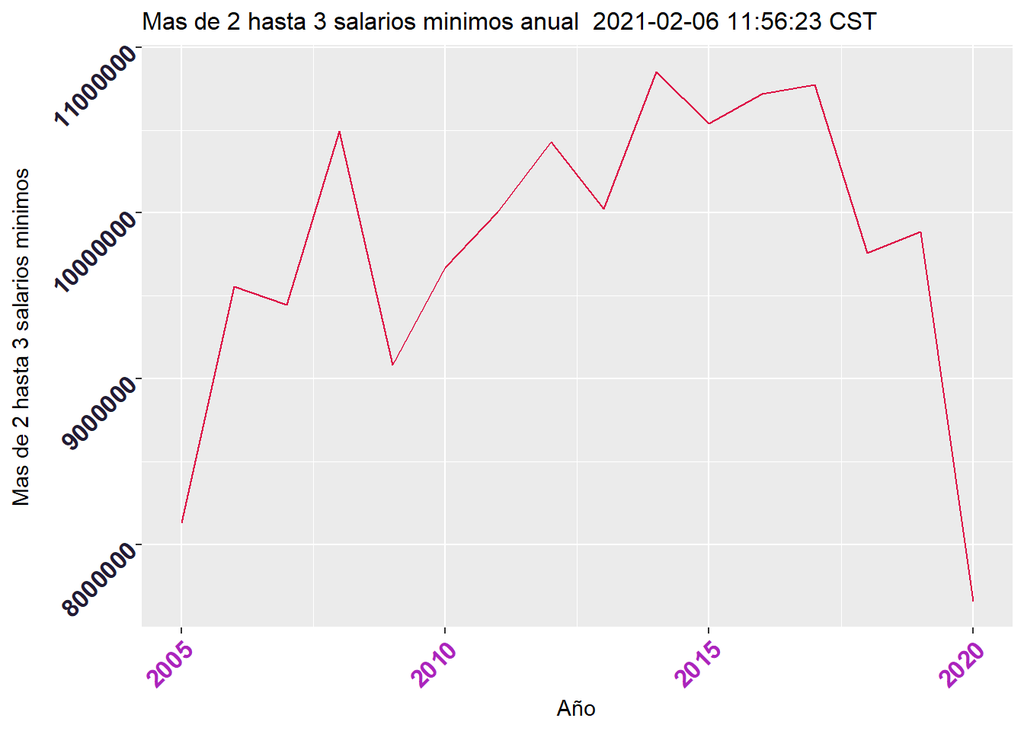

```r
ggplot(Salarios, aes(x=Año, y=Salarios$dos3salariomin)) + geom_line(color="red") +
   labs(x = "Año",
        y = "Mas de 2 hasta 3 salarios minimos",
        title = paste("Mas de 2 hasta 3 salarios minimos anual ", format(Sys.time(), tz="America/Mexico_City",usetz=TRUE))) +
   geom_line(color = "#dd1145") + theme(plot.title = element_text(size=12)) +
   theme(axis.text.x = element_text(face = "bold", color="#ab24bc" , size = 12, angle = 45, hjust = 1),
         axis.text.y = element_text(face = "bold", color="#221b33" , size = 12, angle = 45, hjust = 1))
```

Igualmente en esta grafica el desceso es muy radical, que la pasada por lo cual uno puede considerar que hubo recorte de sueldo:

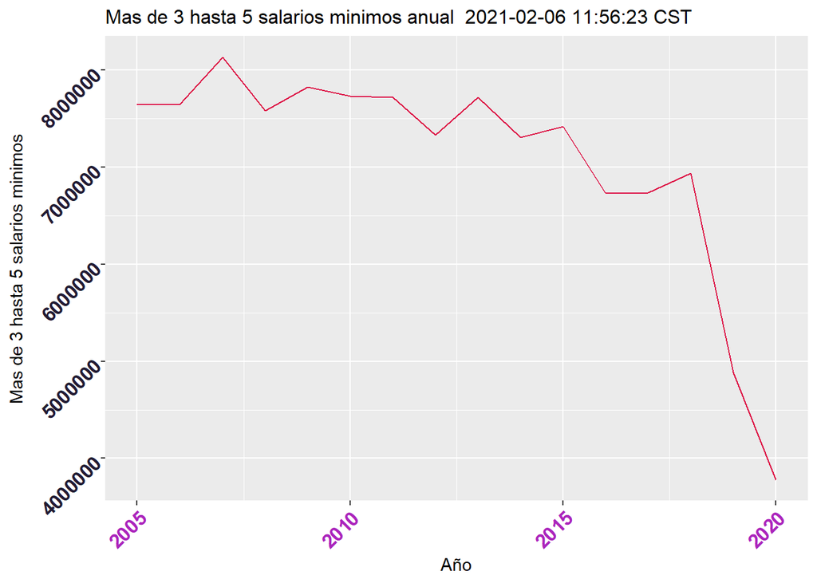

```r
ggplot(Salarios, aes(x=Año, y=Salarios$tres5saliomin)) + geom_line(color="red") +
   labs(x = "Año",
        y = "Mas de 3 hasta 5 salarios minimos",
        title = paste("Mas de 3 hasta 5 salarios minimos anual ", format(Sys.time(), tz="America/Mexico_City",usetz=TRUE))) +
   geom_line(color = "#dd1145") + theme(plot.title = element_text(size=12)) +
   theme(axis.text.x = element_text(face = "bold", color="#ab24bc" , size = 12, angle = 45, hjust = 1),
         axis.text.y = element_text(face = "bold", color="#221b33" , size = 12, angle = 45, hjust = 1))
```

```r
#names(salarios2018)
```

Observaremos mas a detalle cada uno de los años por lo cual, usaremos el datos y obtendremos los a;os a partir del 2019:

```r
salarios2018 <- datos[datos$Año > 2018, ]
salarios2018 <-select(salarios2018, Año, Mes, X3.3.Nivel.de.ingresos:No.especificado.2)
salarios2018 <- na.omit(salarios2018)
# salarios2018
fecha<-salarios2018[,1:2]

salarios2018 <- mutate(salarios2018, Fecha=salarios2018[,1:2])
# salarios2018
class(salarios2018)
```

```
[1] "data.frame"
```

Graficaremos estos a;os para visualizar los meses más afectados:

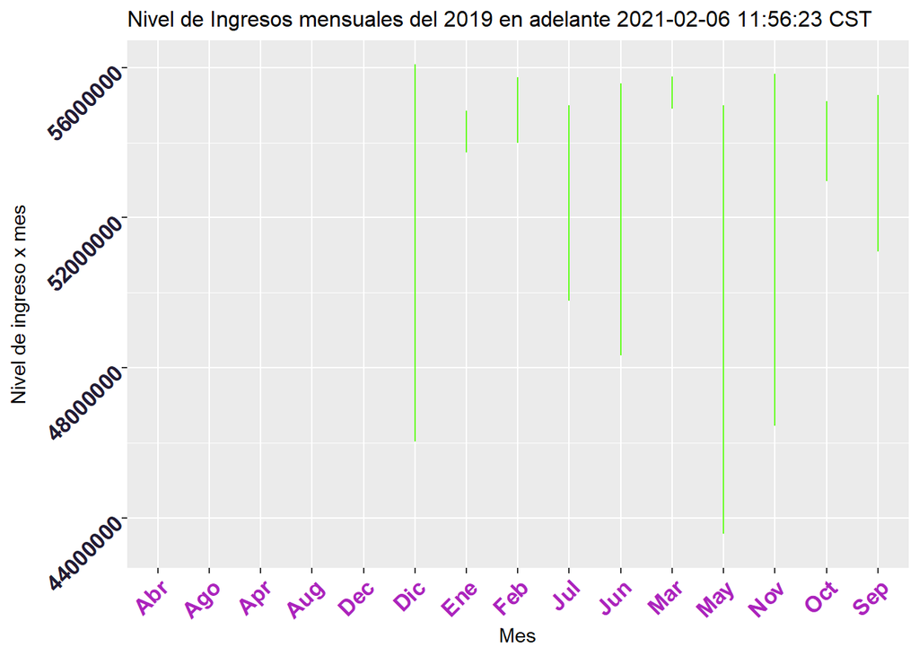

```r
ggplot(salarios2018, aes(x=salarios2018$Mes, y=salarios2018$X3.3.Nivel.de.ingresos)) + geom_line(color="#723def") +
   labs(x = "Mes",
        y = "Nivel de ingreso x mes",
        title = paste("Nivel de Ingresos mensuales del 2019 en adelante", format(Sys.time(), tz="America/Mexico_City",usetz=TRUE))) +
   geom_line(color = "#65ff22") + theme(plot.title = element_text(size=12)) +
   theme(axis.text.x = element_text(face = "bold", color="#ab24bc" , size = 12, angle = 45, hjust = 1),
         axis.text.y = element_text(face = "bold", color="#221b33" , size = 12, angle = 45, hjust = 1))
```

```r
# View(datos)
names(datos)
```

```
 [1] "Año"
 [2] "Mes"
 [3] "Población.total"
 [4] "Población.de.15.años.y.más"
 [5] "Población.económicamente.activa..PEA."
 [6] "PEA.Ocupada"
 [7] "PEA.Desocupada"
 [8] "Población.no.económicamente.activa..PNEA."
 [9] "PNEA.Disponible"
[10] "PNEA.No.disponible"
[11] "X3..Población.ocupada.por"
[12] "X3.1.Posición.en.la.ocupación"
[13] "Trabajadores.subordinados.y.remunerados"
[14] "Empleadores"
[15] "Trabajadores.por.cuenta.propia"
```

[output cut: 44 more lines]

```r
# str(datos)
```

MODELAJE DE SERIES DE TIEMPO

```r
empleo <- datos
attach(empleo)

#Escenario sobre efecto de la pandemia suponiendo que dure 12 meses más
covid_reg_for<-rep(1,12)

######################################################################

#Análisis general de impacto en el empleo

#Creación de series de tiempo

empleo_ts = ts(PEA.Ocupada/1000000, start = 2005, frequency = 12)
covid_reg = ts(COVID.19, start = 2005, frequency = 12)
```

Exploración inicial

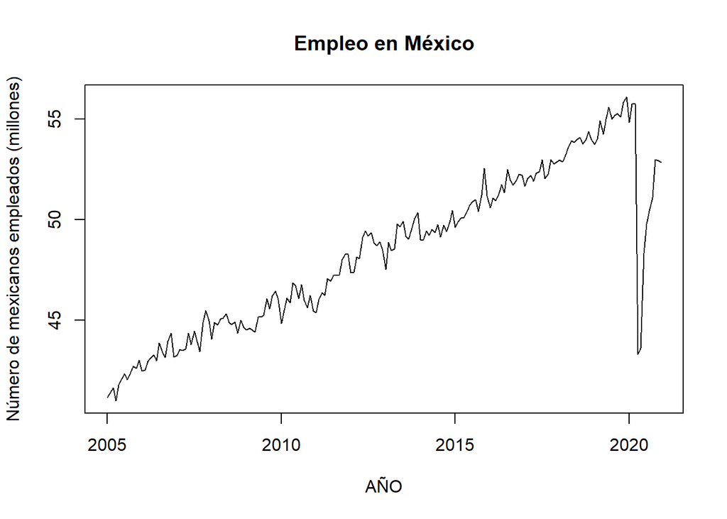

```r
plot(empleo_ts, xlab = "", ylab = "")
title(main = "Empleo en México",
      ylab = "Número de mexicanos empleados (millones)",
      xlab = "AÑO")
```

```r
#Creación del modelo ARIMAX

empleo_arima <-auto.arima(empleo_ts, xreg = covid_reg)
summary(empleo_arima)
```

```
Series: empleo_ts
Regression with ARIMA(0,1,1)(0,0,2)[12] errors

Coefficients:
          ma1    sma1    sma2   drift      xreg
      -0.1088  0.1739  0.2545  0.1432  -12.5048
s.e.   0.0736  0.0953  0.0944  0.0555    0.6204

sigma^2 estimated as 0.3894:  log likelihood=-179.33
AIC=370.66   AICc=371.12   BIC=390.17

Training set error measures:
                      ME      RMSE       MAE          MPE      MAPE      MASE
Training set 0.001456018 0.6141703 0.4239475 -0.006468194 0.8776541 0.3421782
                    ACF1
Training set 0.003927993
```

[figure not shown]

```r
#Evaluación del modelo

acf(resid(empleo_arima), main = "")
title(main = "Autocorrelaciones para los Residuales del Ajuste",
      sub = expression(x[t]==x[t-1]+w[t]-0.33*w[t-1]))
```

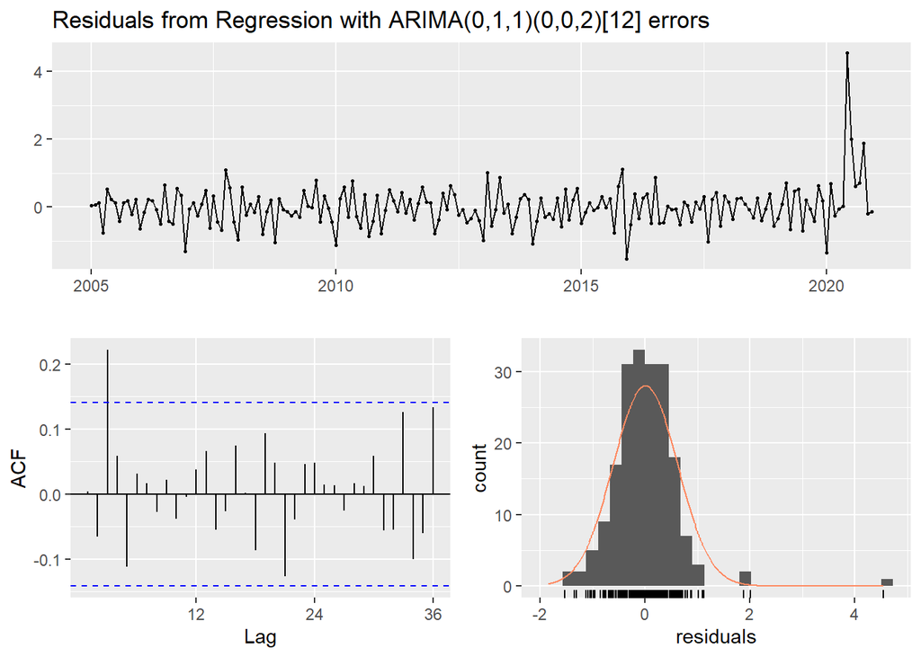

```
    Ljung-Box test

data:  Residuals from Regression with ARIMA(0,1,1)(0,0,2)[12] errors
Q* = 26.5, df = 19, p-value = 0.1168

Model df: 5.   Total lags used: 24
```

```r
checkresiduals(empleo_arima)
```

Pronostico del modelo

```r
empleo_for <-forecast(empleo_arima,xreg=covid_reg_for,h=12)
empleo_for
```

```
         Point Forecast    Lo 80    Hi 80    Lo 95    Hi 95
Jan 2021       52.68526 51.88558 53.48495 51.46225 53.90828
Feb 2021       53.00723 51.93606 54.07839 51.36902 54.64544
Mar 2021       53.27325 51.98667 54.55984 51.30559 55.24092
Apr 2021       53.22427 51.75348 54.69505 50.97490 55.47364
May 2021       53.50980 51.87545 55.14416 51.01028 56.00933
Jun 2021       54.56485 52.78188 56.34783 51.83802 57.29168
Jul 2021       54.77997 52.85984 56.70010 51.84338 57.71656
Aug 2021       55.06130 53.01317 57.10942 51.92896 58.19363
Sep 2021       55.29658 53.12801 57.46516 51.98004 58.61313
Oct 2021       55.64806 53.36538 57.93073 52.15700 59.13911
Nov 2021       55.89507 53.50373 58.28642 52.23783 59.55232
Dec 2021       56.04891 53.55363 58.54419 52.23270 59.86511
```

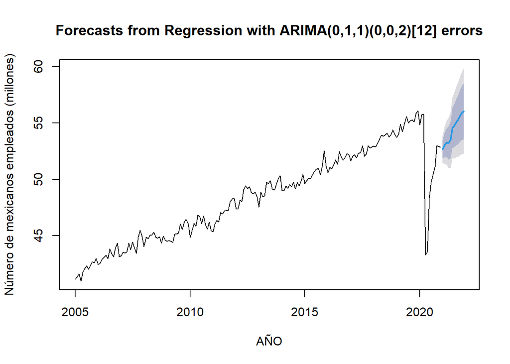

```r
plot(empleo_for)
title(main = "",
      ylab = "Número de mexicanos empleados (millones)",
      xlab = "AÑO")
```

Insertar en tabla de medias

```r
media_empleo_2019<-round(mean(empleo[169:180,"PEA.Ocupada"])/1000000,2)
media_empleo_2020<-round(mean(empleo[181:192,"PEA.Ocupada"])/1000000,2)
media_empleo_2021<-round(mean(empleo_for$fitted,2))

#Creación de tabla de medias

tabla_de_medias <-data.frame(rbind(c("Empleo", media_empleo_2019,media_empleo_2020,media_empleo_2021)))
colnames(tabla_de_medias)<-c("Serie", "Media 2019 (millones)","Media 2020 (millones)","Media 2021(pronóstico | millones)")
```

## ANALISIS POR SECTOR ECONÓMICO

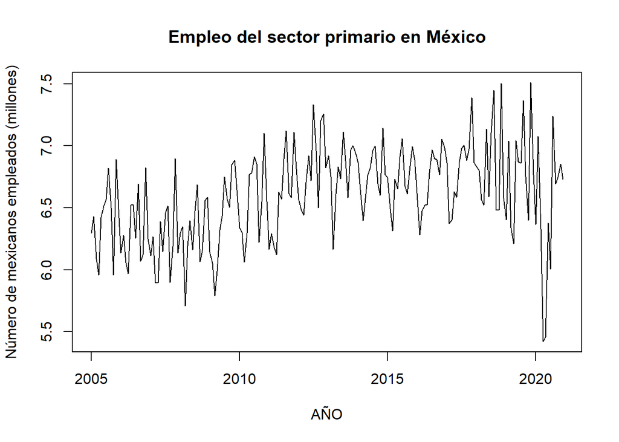

```r
##Primario

primario_ts = ts(Primario/1000000, start = 2005, frequency = 12)


#Exploración inicial

plot(primario_ts, xlab = "", ylab = "")
title(main = "Empleo del sector primario en México",
      ylab = "Número de mexicanos empleados (millones)",
      xlab = "AÑO")
```

```r
#Creación del modelo ARIMAX

primario_arima <-auto.arima(primario_ts, xreg = covid_reg)
summary(primario_arima)
```

```
Series: primario_ts
Regression with ARIMA(1,0,2)(0,1,1)[12] errors

Coefficients:
         ar1      ma1     ma2     sma1   drift     xreg
      0.8154  -0.7783  0.2449  -0.5963  0.0037  -0.7447
s.e.  0.1241   0.1213  0.1284   0.1211  0.0017   0.1787

sigma^2 estimated as 0.05296:  log likelihood=9.29
AIC=-4.57   AICc=-3.92   BIC=17.78

Training set error measures:
                       ME      RMSE       MAE        MPE    MAPE      MASE
Training set -0.002818246 0.2190768 0.1596766 -0.1302503 2.43055 0.7900817
                   ACF1
Training set 0.02597731
```

[figure not shown]

```r
#Evaluación del modelo

acf(resid(primario_arima), main = "")
title(main = "Autocorrelaciones para los Residuales del Ajuste",
      sub = expression(x[t]==x[t-1]+w[t]-0.33*w[t-1]))
```

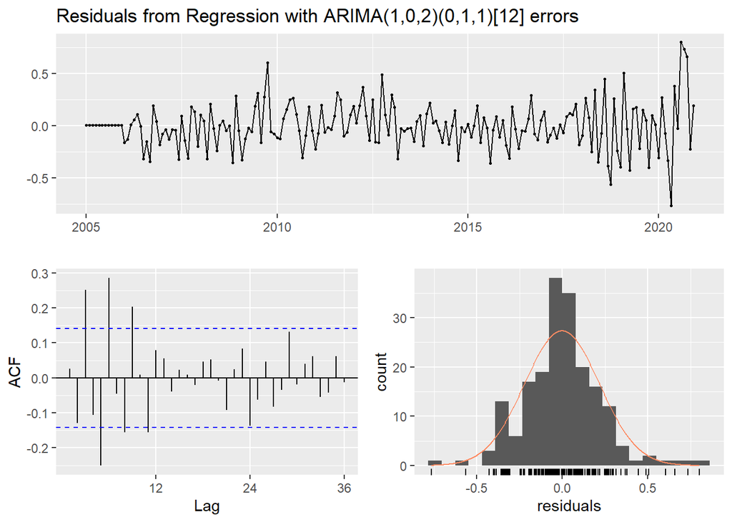

```
    Ljung-Box test

data:  Residuals from Regression with ARIMA(1,0,2)(0,1,1)[12] errors
Q* = 76.725, df = 18, p-value = 0.000000003186

Model df: 6.   Total lags used: 24
```

```r
checkresiduals(primario_arima)
```

Pronostico del modelo

```r
primario_for <-forecast(primario_arima,xreg=covid_reg_for,h=12)
primario_for
```

```
         Point Forecast    Lo 80    Hi 80    Lo 95    Hi 95
Jan 2021       6.176007 5.881085 6.470930 5.724962 6.627053
Feb 2021       6.533125 6.237999 6.828251 6.081769 6.984482
Mar 2021       5.971715 5.665632 6.277798 5.503601 6.439829
Apr 2021       5.872063 5.558907 6.185220 5.393132 6.350995
May 2021       6.144712 5.826940 6.462485 5.658721 6.630703
Jun 2021       6.412499 6.091694 6.733304 5.921870 6.903128
Jul 2021       6.347496 6.024690 6.670301 5.853807 6.841184
Aug 2021       6.980886 6.656757 7.305014 6.485173 7.476598
Sep 2021       6.430374 6.105368 6.755380 5.933321 6.927427
Oct 2021       6.369128 6.043540 6.694715 5.871185 6.867071
Nov 2021       6.887147 6.561173 7.213121 6.388613 7.385681
Dec 2021       6.453599 6.127369 6.779829 5.954673 6.952525
```

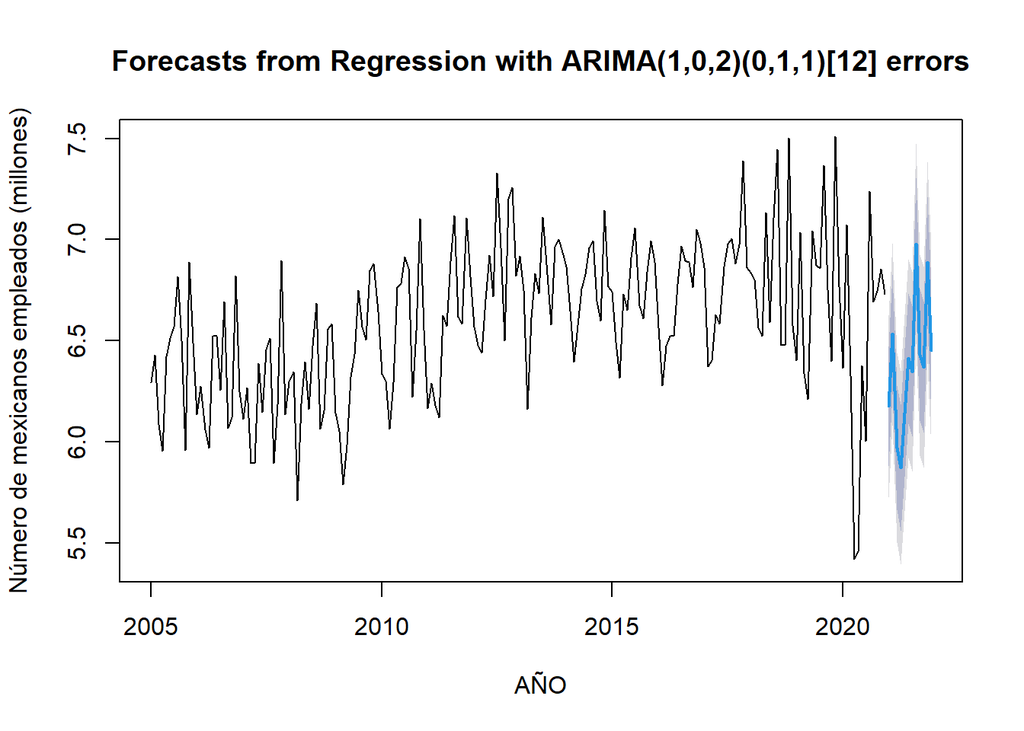

```r
plot(primario_for)
title(main = "",
      ylab = "Número de mexicanos empleados (millones)",
      xlab = "AÑO")
```

```r
#Insertar resultados en la tabla de medias

media_primario_2019<-round(mean(empleo[169:180,"Primario"]/1000000),2)
media_primario_2020<-round(mean(empleo[181:192,"Primario"]/1000000),2)
media_primario_2021<-round(primario_for$mean,2)
tabla_de_medias <-rbind(tabla_de_medias,c("Sector Primario", media_primario_2019,media_primario_2020,media_primario_2021))
```

Sector secundario

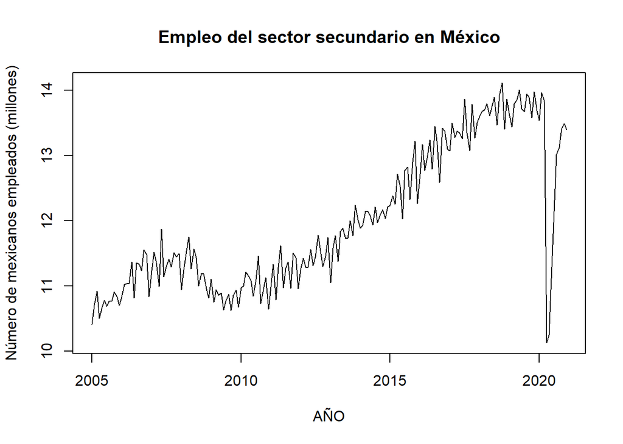

```r
##Secundario

secundario_ts = ts(Secundario/1000000, start = 2005, frequency = 12)


#Exploración inicial

plot(secundario_ts, xlab = "", ylab = "")
title(main = "Empleo del sector secundario en México",
      ylab = "Número de mexicanos empleados (millones)",
      xlab = "AÑO")
```

```r
#Creación del modelo ARIMAX

secundario_arima <-auto.arima(secundario_ts, xreg = covid_reg)
summary(secundario_arima)
```

```
Series: secundario_ts
Regression with ARIMA(4,1,0) errors

Coefficients:
          ar1      ar2     ar3     ar4   drift     xreg
      -0.4130  -0.1468  0.4216  0.1797  0.0373  -4.1091
s.e.   0.0712   0.0760  0.0766  0.0763  0.0209   0.2695

sigma^2 estimated as 0.07985:  log likelihood=-27.05
AIC=68.1   AICc=68.71   BIC=90.86

Training set error measures:
                      ME      RMSE       MAE         MPE     MAPE      MASE
Training set 0.001068099 0.2773767 0.2093396 -0.01401172 1.751438 0.5111725
                   ACF1
Training set 0.01472345
```

[figure not shown]

```r
#Evaluación del modelo

acf(resid(secundario_arima), main = "")
title(main = "Autocorrelaciones para los Residuales del Ajuste",
      sub = expression(x[t]==x[t-1]+w[t]-0.33*w[t-1]))
```